# Take Home Exam #1

Micaiah Balonek

February 24, 2024

## Rules

```r
2 + 2
# 4
```

1. You may only use `tidyverse` and `nycflights13` (and its dependencies) for this assignment. Your solutions may not use any other R packages.

## Academic Integrity Statement

*I, Micaiah Balonek, hereby state that I have not communicated with or gained information in any way from my classmates or anyone other than the Professor or TA during this exam, and that all work is my own.*

**A note on sharing / reusing code:** I am well aware that a huge volume of code is available on the web to solve any number of problems. For this exam you are allowed to make use of any online resources (e.g. StackOverflow) but you must explicitly cite where you obtained any code you directly use (or use as inspiration). You are also not allowed to ask a question on an external forum, you can only use answers to questions that have already been answered. Any recycled code that is discovered and is not explicitly cited will be treated as plagiarism. All communication with classmates is explicitly forbidden.

## Getting help

You are not allowed to post any questions on the public community repo or the public questions channel on Slack. Any questions about the exam must be asked in person in office hours or on Slack via direct message to the Professor or the TAs. For quickest response we recommend that you start a direct message with the Professor and all the TAs so that whoever gets to it first can respond to you.

## Grading and feedback

The total points for the questions add up to 90 points. The remaining 10 points are allocated to code style, commit frequency and messages, overall organization, spelling, grammar, etc. There is also an extra credit question that is worth 5 points. You will receive feedback as an issue posted to your repository, and your grade will also be recorded on Sakai.

## Logistics

Answer the questions in the document called `exam-01.Rmd`. Add your code and narrative in the spaces below each question. Add code chunks as needed. Use as many lines as you need, but keep your narrative concise.

Before completing, make sure to supress the code and look over your answers one more time. If the narrative seems sparse or choppy, edit as needed. Then, revert back to revealing your code.

Don’t forget that you will need to configure your user name and email for Git to be able to push to your repository.

## Packages

In addition to `tidyverse`, you will need the `nycflights13` package for the data. You will first need to install these packages and then load them.

## The data

The `nycflights13` package contains information about all flights that departed from NYC (e.g. EWR, JFK and LGA) in 2013. The main data is in the `flights` data frame, but there are additional data sets which may help understand what causes delays, specifically:

- `weather`: hourly meteorological data for each airport
- `planes`: construction information about each plane
- `airports`: airport names and locations
- `airlines`: translation between two letter carrier codes and names

## Questions

1. **Question 1 (10 points)** - What are the ten most common destinations for flights from NYC airports in 2013? Make a table that lists these in descending order of frequency and shows the number of fligts heading to each airport.

```r
nycflights13::flights %>%
  count(dest) %>%
  arrange(desc(n)) %>%
  slice(1:10)
```

```
## # A tibble: 10 × 2
##    dest      n
##    <chr> <int>
##  1 ORD   17283
##  2 ATL   17215
##  3 LAX   16174
##  4 BOS   15508
##  5 MCO   14082
##  6 CLT   14064
##  7 SFO   13331
##  8 FLL   12055
##  9 MIA   11728
## 10 DCA    9705
```

- *To find the top ten most frequent destinations, we take the `flights` dataset from the `nycflights13` package, count how many flights ended at each destination, sort them by descending number of flights, and select only the first 10 values. The top 10 most common destinations are, according to this pipeline, ORD, ATL, LAX, BOS, MCO, CLT, SFO, FLL, MIA, and DCA.*
2. **Question 2 (10 points)** - Which airlines have the most flights departing from NYC airports in 2013? Make a table that lists these in descending order of frequency and shows the number of flights for each airline. In your narrative mention the names of the airlines as well. *Hint:* You can use the `airlines` dataset to look up the airline name based on `carrier` code.

```r
nycflights13::flights %>%
  inner_join(nycflights13::airlines,
            by = "carrier") %>%
  mutate(airline = name, .keep = "unused") %>%
  count(airline) %>%
  arrange(desc(n))
```

```
## # A tibble: 16 × 2
##    airline                         n
##    <chr>                       <int>
##  1 United Air Lines Inc.       58665
##  2 JetBlue Airways             54635
##  3 ExpressJet Airlines Inc.    54173
##  4 Delta Air Lines Inc.        48110
##  5 American Airlines Inc.      32729
##  6 Envoy Air                   26397
##  7 US Airways Inc.             20536
##  8 Endeavor Air Inc.           18460
##  9 Southwest Airlines Co.      12275
## 10 Virgin America               5162
## 11 AirTran Airways Corporation  3260
## 12 Alaska Airlines Inc.          714
## 13 Frontier Airlines Inc.        685
## 14 Mesa Airlines Inc.            601
## 15 Hawaiian Airlines Inc.        342
## 16 SkyWest Airlines Inc.          32
```

- *To solve this question, we take the flights data, and add an extra column “`airline`” for the name of the airline (joining the `airlines` dataframe to the destination codes of the `flights` dataframe), count how many flights were from each airline, and sort them in descending order of frequency. The four airlines with the most departing flights are United Airlines, JetBlue Airways, ExpressJet Airlines, and Delta Airlines.*
3. **Question 3 (10 points)** - Consider only flights that have non-missing arrival delay information. Your answer should include the name of the carrier in addition to the carrier code and the values asked.

```r
carrier_delays <- nycflights13::flights %>%
  filter(!is.na(arr_delay))  %>%
  group_by(carrier) %>%
  summarise(mean_delay = mean(arr_delay))  %>%
  inner_join(nycflights13::airlines,
            by = "carrier") %>%
  mutate(carrier_name = name, carrier_code = carrier, .keep = "unused")
```

- *To find the mean arrival delay of each airline, we start by removing the flights with missing values of delays. We then group by the carrier codes of the flights and take the mean of the arrival delays for each carrier code. We then add in the name of the carrier using the airlines dataframe, rename the variables to be more clear, and save this into a new dataframe. To answer the questions, we slice off the minimum and maximum mean values using inline code.*

  a. Which carrier had the highest mean arrival delay?
- *The airline carrier with the highest mean delay in 2013 was Frontier Airlines Inc., with code F9*

  b. Which carrier had the lowest mean arrival delay?
- *The airline carrier with the lowest mean delay in 2013 was Alaska Airlines Inc., with code AS*
4. **Question 4 (10 points)** - What was the mean temperature at the origin airport on the day with the highest departure delay? Your answer should include the name of origin airport, the date with the highest departure delay, and the mean temperature on that day.

```r
highest_delay <- nycflights13::flights %>%
  mutate(date = str_c(day, "/", month, "/", year)) %>%
  arrange(desc(dep_delay)) %>%
  slice(1)

nycflights13::weather %>%
  mutate(date = str_c(day, "/", month, "/", year)) %>%
  filter(date == highest_delay$date,
         origin == highest_delay$origin) %>%
  select(origin, date, temp) %>%
  summarise(origin = origin[1], date = date[1], mean_temp = mean(temp))
```

```
## # A tibble: 1 × 3
##   origin date     mean_temp
##   <chr>  <chr>        <dbl>
## 1 JFK    9/1/2013      42.7
```

- *We start by combining the `day`, `month`, and `year` variables in the flights dataframe into a single `date` variable, sorting by descending order of departure delay, and select only the top row of the dataframe, and assign this to a new variable. We then turn to the `weather` dataframe and mutate the date variable into it as well, before filtering for those with the same date value and origin airport and taking the mean of all the temperatures still in the dataframe. According to this data, the flight with the highest departure delay left from John F. Kennedy Airport on January 9th, 2013, and the mean temperature there on that day was about 43 degrees Fahrenheit.*
5. **Question 5 (15 points)** - Consider breaking the day into four time intervals: 12:01am-6am, 6:01am-12pm, 12:01pm-6pm, 6:01pm-12am.

```r
flight_time_ints <- nycflights13::flights %>%
  mutate(time_int = case_when(
    hour %in% 0:5 ~ "am 12:01-6:00",
    hour %in% 6:11 ~ "am 6:01-12:00",
    hour %in% 12:17 ~ "pm 12:01-6:00",
    hour %in% 18:24 ~ "pm 6:01-12:00"
  ))
```

- *In this first pipeline, we add a variable to the flights dataframe, determining which quarter of the day the flight was in, and then save it to a new dataframe*

  a. Calculate the proportion of flights that are delayed at departure at each of these time intervals.

```r
flight_time_ints %>%
  group_by(time_int) %>%
  reframe(., prop_delayed = group_size(filter(., dep_delay > 0))/group_size(.)) %>%
  slice(1, 6, 11, 16)
```

```
## # A tibble: 4 × 2
##   time_int      prop_delayed
##   <chr>                <dbl>
## 1 am 12:01-6:00        0.250
## 2 am 6:01-12:00        0.252
## 3 pm 12:01-6:00        0.443
## 4 pm 6:01-12:00        0.501
```

- *To answer this question, we take the data that we made in the previous code chunk, group it by the time interval, and calculate the proportion of flights that are delayed in each group. In this code, we can see that the proportion is about 25% both from midnight to 6am and from 6am to noon, 44% from noon to 6pm, and 50% from 6pm to midnight.*

  b. Comment on how the likelihood of being delayed change throughout the day?
- *In the morning (including the part of the night in AM), about a quarter of the flights are delayed, which grows throughout the day until the fourth quarter of the day, when over half the flights are delayed. Perhaps the delays build up through the day, since it gets higher over time, but that doesn’t really explain why flights are no longer as delayed in the early morning compared to in the evening and night.*
6. **Question 6 (15 points)** - Find the flight with the longest air time.

```r
longest_flight13 <- nycflights13::flights %>%
  slice_max(air_time)
```

  a. How long is this flight?
- *According to the data, this flight was 695 minutes (11 hours, 35 minutes) long.*

  b. What city did it fly to?
- *It flew to Honolulu, Hawai’i*

  c. How many seats does the plane that flew this flight have?

```r
longest_flight_plane <- longest_flight13 %>%
  inner_join(nycflights13::planes, "tailnum")
```

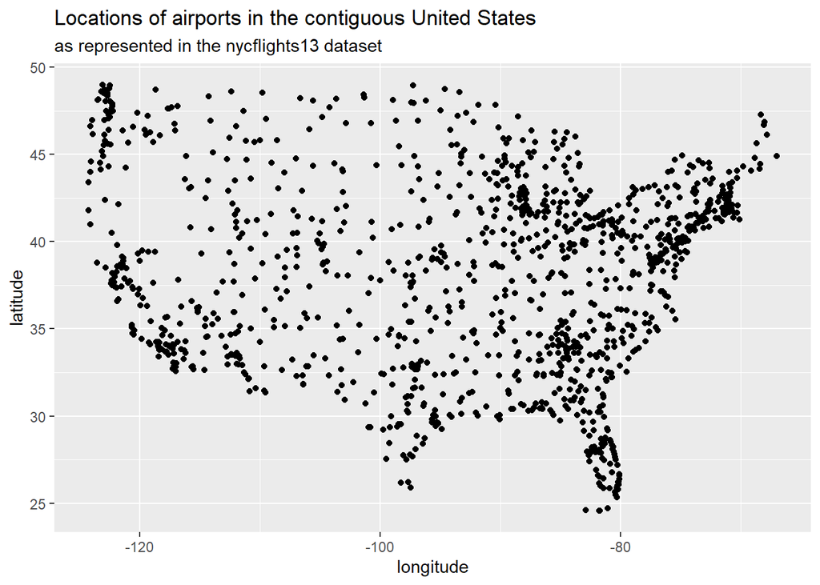

```r
nycflights13::airports %>%
  filter(lon < -66.950,
         lon >  -124.785,
         lat < 49.387) %>%
  ggplot(aes(x = lon, y = lat)) +
  geom_point() +
  labs(title = "Locations of airports in the contiguous United States",
       subtitle = "as represented in the nycflights13 dataset",
       x = "longitude",
       y = "latitude")
```

###### *Geographical data taken from:*

###### *Wikipedia contributors. (2024, February 13). List of extreme points of the United States. In Wikipedia, The Free Encyclopedia. Retrieved 15:10, February 14, 2024, from https://en.wikipedia.org/w/index.php?title=List_of_extreme_points_of_the_United_States&oldid=1207066256*

- *To create this plot, I used data from the previously cited article about the limits of the contiguous United States, filtered to airports within those limits, and plotted them on a graph. The distribution of airports in the plot shows especially-high concentrations of airports around metropolitan areas, as well as a few notable areas with significantly fewer airports (notably the empty regions in the northern Nevada area and northwestern Maine). However, aside from these, the distribution of airports is fairly uniform across the USA, growing more dense further to the east you are, aside from the western seaboard, which is much more densely populated than the surrounding areas.*
8. **Question 8 (15 pts)** - Recreate the plot included below using the `flights` data. Once you have created the visualization, in no more than one paragraph, describe what you think the point of this visualization might be. *Hint:* The visualization uses the variable `arrival`, which is not included in the `flights` data frame. You will have to create `arrival` yourself, it is a categorical variable that is equal to `"ontime"` when `arr_delay <= 0` and `"delayed"` when `arr_delay > 0`.

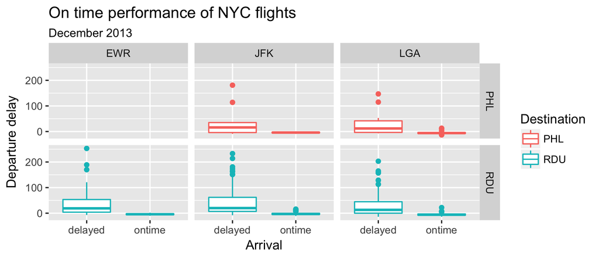

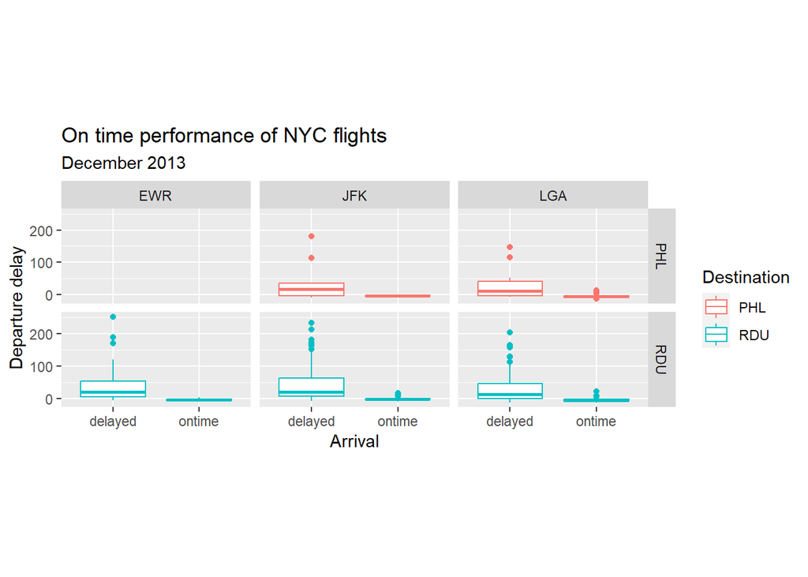

```r
nycflights13::flights %>%
  filter(dest %in% c("RDU", "PHL"),
         month == 12,
         !is.na(arr_delay)) %>%
  mutate(arrival = if_else(arr_delay > 0, "delayed", "ontime")) %>%
  ggplot(aes(x = arrival, y = dep_delay, colour = dest)) +
  geom_boxplot() +
  theme(aspect.ratio = 0.5) +
  facet_grid(dest ~ origin) +
  labs(title = "On time performance of NYC flights",
       subtitle = "December 2013",
       x = "Arrival",
       y = "Departure delay",
       colour = "Destination")
```

- *This chart seems to be comparing the departure delay of flights on different routes in December 2013 with whether they arrived at their destination on time. The title seems to suggest that this chart would be comparing how many flights were delayed vs. on-time, but that would use a histogram, not a box plot. Perhaps the point of the graph is the distribution of departure delays in the delayed category for flights going to different destinations, since the graph shows two seemingly-arbitrary locations? Even this seems dubious, but it seems like the most likely point that I can think of.*

**Extra Credit (5 pts)** - Create a visualization that effectively shows if there is a relationship between the average daily departure delay and the average daily temperature for all three New York city airports. Your answer must be given in a single pipe. (You should only spend time on this question once you have finished answering the others)

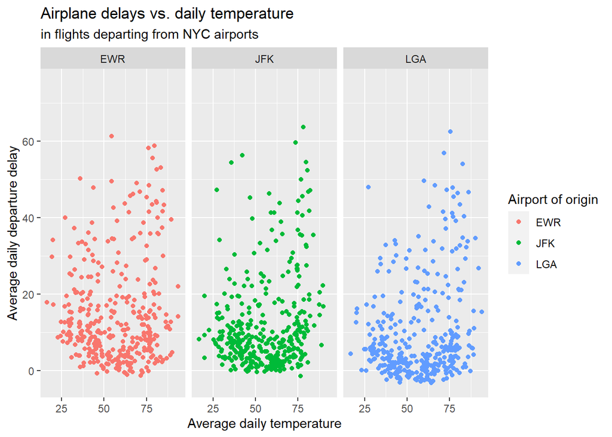

```r
nycflights13::flights %>%
  inner_join(nycflights13::weather,
             join_by(time_hour, hour, year, month, day, origin)) %>%
  group_by(origin, month, day) %>%
  filter(!is.na(temp),
         !is.na(dep_delay)) %>%
  summarise(daily_temp = mean(temp),
            mean_delay = mean(dep_delay)) %>%
  ggplot(aes(x = daily_temp, y = mean_delay, colour = origin)) +
  geom_point() +
  facet_wrap(~ origin) +
  labs(title = "Airplane delays vs. daily temperature",
       subtitle = "in flights departing from NYC airports",
       x = "Average daily temperature",
       y = "Average daily departure delay",
       colour = "Airport of origin") +
  ylim(NA, 75)
```